# Introduction

This vignette goes through the spatial thinning example presented in “spThin: An R package for spatial thinning of species occurrence records for use in ecological niche models”. Here we demonstrate how `spThin` can be used to spatially thin species occurence records, we test how many repetitions of the thinning algorithm are necessary to achieve the optimal number of thinned records for a dataset previously thinned “by hand”, and we examine whether there is a notable increase in efficiency if an occurence dataset is thinned as multiple smaller groups of occurrences, rather than a single large set of occurrences.

# Load the `spThin` R package

Here we load the R package from source code. This source code will soon be submitted to CRAN, so that this package can be loaded using standard package management methods

```r
library( spThin )
```

# Example dataset

To demonstrate the use of `spThin` we used a set of 201 verified, georeferenced occurrence records for the Caribbean spiny pocket mouse *Heteromys anomalus*. These occurrences are from Columbia, Venezuela, and three Caribbean islands: Trinidad, Tobago, and Margarita. This dataset is included as part of the `spThin` package.

#### Load *H. anomalus* dataset

```r
data( Heteromys_anomalus_South_America )
head( Heteromys_anomalus_South_America )
```

```
##       SPEC       LAT      LONG   REGION
## 1 anomalus  7.883333 -75.20000 mainland
## 2 anomalus  8.000000 -76.73333 mainland
## 3 anomalus 10.616667 -75.03333 mainland
## 4 anomalus  8.633333 -74.06667 mainland
## 5 anomalus  9.966667 -75.06667 mainland
## 6 anomalus 10.216667 -73.38333 mainland
```

Here we load and examine the dataset. The name assigned to this dataset is `Heteromys_anomalus_South_America`. Note that this dataset includes a column indicating which REGION the occurrences was collected. Regions here refer to either the mainland or three islands in which an occurrence was collected. We can see that there are many more occurrences collected for the mainland than for the three islands. Note that Trinidad has been shortened to 'trin' an Margarita has been shortened to 'mar'.

```r
table( Heteromys_anomalus_South_America$REGION )
```

```
##
## mainland      mar   tobago     trin
##      174        2        4       21
```

# Run `spThin::thin` on the full dataset

`thin` involves multiple settings. This allows for extensive flexibility in how the user spatially thins a dataset. However, many have default values. See `?thin` for further information.

```r
thinned_dataset_full <-
  thin( loc.data = Heteromys_anomalus_South_America,
        lat.col = "LAT", long.col = "LONG",
        spec.col = "SPEC",
        thin.par = 10, reps = 100,
        locs.thinned.list.return = TRUE,
        write.files = FALSE,
        write.log.file = FALSE)
```

```
##  Beginning Spatial Thinning.
##  Script Started at: Thu Nov 14 16:48:24 2019
## lat.long.thin.count
## 122 123 124
##  17  43  40
## [1] "Maximum number of records after thinning: 124"
## [1] "Number of data.frames with max records: 40"
## [1] "No files written for this run."
```

Below is the same call, but in this case we are writing a number of files to disk. This files include a set of *.csv files of the thinned data and a log file.

```r
thinned_dataset_full <-
  thin( loc.data = Heteromys_anomalus_South_America,
        lat.col = "LAT", long.col = "LONG",
        spec.col = "SPEC",
        thin.par = 10, reps = 100,
        locs.thinned.list.return = TRUE,
        write.files = TRUE,
        max.files = 5,
        out.dir = "hanomalus_thinned_full/", out.base = "hanomalus_thinned",
        write.log.file = TRUE,
        log.file = "hanomalus_thinned_full_log_file.txt" )
```

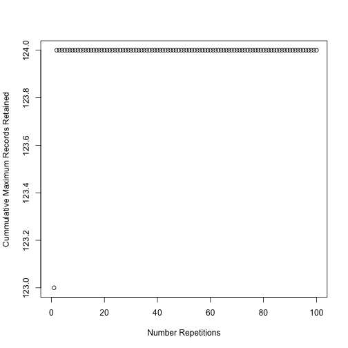

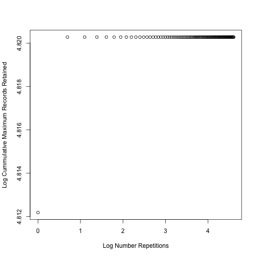

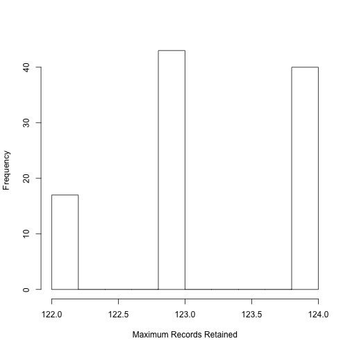

```r
plotThin( thinned_dataset_full )
```

# Run `spThin::thin` on datasets separated by region

#### Coastal mainland

```r
thinned_dataset_mainland <-
  thin( loc.data = Heteromys_anomalus_South_America[ which( Heteromys_anomalus_South_America$REGION == "mainland" ) , ],
        lat.col = "LAT", long.col = "LONG",
        spec.col = "SPEC",
        thin.par = 10, reps = 100,
        locs.thinned.list.return = TRUE,
        write.files = FALSE,
        write.log.file = FALSE)
```

```
##  Beginning Spatial Thinning.
##  Script Started at: Thu Nov 14 16:48:25 2019
## lat.long.thin.count
## 109 110
##  30  70
## [1] "Maximum number of records after thinning: 110"
## [1] "Number of data.frames with max records: 70"
## [1] "No files written for this run."
```

### Trinidad

```r
thinned_dataset_trin <-
  thin( loc.data = Heteromys_anomalus_South_America[ which( Heteromys_anomalus_South_America$REGION == "trin" ) , ],
        lat.col = "LAT", long.col = "LONG",
        spec.col = "SPEC",
        thin.par = 10, reps = 10,
        locs.thinned.list.return = TRUE,
        write.files = FALSE,
        write.log.file = FALSE)
```

```
##  Beginning Spatial Thinning.
##  Script Started at: Thu Nov 14 16:48:25 2019
## lat.long.thin.count
## 11 12
##  1  9
## [1] "Maximum number of records after thinning: 12"
## [1] "Number of data.frames with max records: 9"
## [1] "No files written for this run."
```

### Margarita

```r
thinned_dataset_mar <-
  thin( loc.data = Heteromys_anomalus_South_America[ which( Heteromys_anomalus_South_America$REGION == "mar" ) , ],
        lat.col = "LAT", long.col = "LONG",
        spec.col = "SPEC",
        thin.par = 10, reps = 10,
        locs.thinned.list.return = TRUE,
        write.files = FALSE,
        write.log.file = FALSE )
```

```
##  Beginning Spatial Thinning.
##  Script Started at: Thu Nov 14 16:48:25 2019
## lat.long.thin.count
##  1
## 10
## [1] "Maximum number of records after thinning: 1"
## [1] "Number of data.frames with max records: 10"
## [1] "No files written for this run."
```

### Tobago

```r
thinned_dataset_tobago <-
  thin( loc.data = Heteromys_anomalus_South_America[ which( Heteromys_anomalus_South_America$REGION == "tobago" ) , ],
        lat.col = "LAT", long.col = "LONG",
        spec.col = "SPEC",
        thin.par = 10, reps = 10,
        locs.thinned.list.return = TRUE,
        write.files = FALSE,
        write.log.file = FALSE )
```

```
##  Beginning Spatial Thinning.
##  Script Started at: Thu Nov 14 16:48:25 2019
## lat.long.thin.count
##  1
## 10
## [1] "Maximum number of records after thinning: 1"
## [1] "Number of data.frames with max records: 10"
## [1] "No files written for this run."
```